# Introduction to gsrc

Fabian Grandke

2016-10-17

# Introduction

This vignette gives an introduction to the R package *gsrc*. It explains the overall workflow and provides details about important steps in the pipeline to calculate and visualize genomic rearrangements including duplications, deletions and homeologous exchanges in allopolyploid specied. The goal is to obtain genotypes, copy number variations (CNVs) and translocations.

We demonstrate the process with our own data (*Brassica napus*) from the package *Brassica_napus_data*. Raw data files are too large to be included for all samples. We add raw data of two samples for demonstration purpose of the first steps. The remainder of our data set is included as processed R data.

# Installation

```r
library(gsrc)
require(devtools)
devtools::install_github("grafab/brassicaData")
```

# Input data

One data source for this package are idat files. The user might want to use `list.files` to read in all files from a directory. The red and green signal files should be in alternating order because the prefix is identical.

```r
files <- list.files("/YOUR/DATA/REPOSITORY/",
                    pattern = "idat",full.names = TRUE)
```

We load our example data:

```r
files <- list.files(system.file("extdata",
                                package = "brassicaData"),
                    full.names = TRUE,
                    pattern = "idat")
```

## Sample names

idat files usually have cryptic names. In order to assign “understandable” sample names we need to read in the sample sheets with `read_sample_sheets`.

```r
samples <- read_sample_sheets(files =
                                list.files(system.file("extdata",package = "brassicaData"),
                                           full.names = TRUE,
                                           pattern = "csv"))
```

Users might want to remove all control samples (e.g. H2O) and update the vector of file names `files` from a real dataset. For instance:

```r
controls <- grep("H2O", samples$Names)
if(length(controls) > 0) samples <- samples[-controls, ]
files <- grep(paste(samples$ID, collapse = "|"), files, value = TRUE)
```

The example sample sheet in *brassicaData* does not include any control samples.

`files` contains the full path names of the remaining idat files. We trim the paths to the actual file name and use it as columns names for our raw data file. For Unix file systems this can be done like this:

```r
column_names <- sapply(strsplit(files, split = "/"), FUN=function(x) x[length(x)])
```

## SNP names and positions

SNP identifiers provided by the manufracturers are ofter cryptic and not reasonable. Therefore we transform them into meaningful names. `dictionary` is an R object to translate the cryptic SNP identifiers in the idat files to meaningful SNP names for the example dataset.

Further we need positional information about each SNP to locate it on the genome. `chrPos` provides chromosome and position information for the SNPs in the example dataset. We provide multiple files, because there are different ways to locate the SNPs on the genomes. For other arrays these positions can be obtained by blasting the SNP sequences onto the reference sequence and filtering out SNPs which have multiple or low scoring hits.

```r
data(dictionary, package = "brassicaData", envir = environment())
head(dictionary)
```

```
##     idatID             name
## 1 29697421 Bn-A01-p10000230
## 2 21671449  Bn-A01-p1000115
## 3 17733365  Bn-A01-p1001022
## 4 29773390 Bn-A01-p10013185
## 5 27616423 Bn-A01-p10026020
## 6 51717341 Bn-A01-p10027328
```

```r
data(chrPos, package = "brassicaData", envir = environment())
head(chrPos)
```

```
##             name chromosome position
## 3   Bn-A01-p5512        A01     5435
## 4   Bn-A01-p6239        A01     6089
## 9  Bn-A01-p11933        A01    11833
## 23 Bn-A01-p71129        A01    70979
## 29 Bn-A01-p80385        A01    80347
## 33 Bn-A01-p88608        A01    88548
```

It is advantagous to load the positional information before the raw data because SNPs with unknown positions are usually not of interest and should be skipped from the analysis to reduce computational time and save memory.

# Read in idat files

The raw data will be read using the command `read_internsities` creating a new object `raw_data`. `read_internsities` is a wrapper to the `readIDAT` function from [*illuminaio*](http://bioconductor.org/packages/release/bioc/html/illuminaio.html).

```r
raw_data <- read_intensities(files = files,
                             dict = dictionary,
                             cnames = column_names,
                             pos = chrPos)
```

Inspection shows that it is a list of the information we provided (e.g. positions and chromosomes) and the raw data values from the idat files. Further, we see the number of SNPs and samples.

```r
str(raw_data)
```

We rename the samples to get meaningful names and improve interpretability of the data.

```r
raw_data <- rename_samples(raw_data,
                           samples = samples[,2:1],
                           suffix = c("_Grn", "_Red"))
```

We set up a raw data object including 304 samples of our dataset, which can be loaded from the *brassicaData* package.

```r
data(raw_napus, package = "brassicaData", envir = environment())
```

# Preprocessing

Now that we read in the raw data it is time that we combine the green and red signal for each sample.

## Quality control

We check the quality of our data and remove failed samples or SNPs. Signal intensities are a good indicators if genotyping of a sample failed. Similarly, we can use the number of beads and standard deviations to detect erroneous SNPs. We did not include the latter ones in our example dataset because it would triple the required memory. However, the command `filt_snps` provides the required functionality.

### Signal intensities

We have a look at the raw data values. The histogram shows the mean red and green values for each sample. Outliers on the left side might should be inspected and probably filtered out. The threshold returns the indices of the green and red value for the sample below the threshold.

```r
check_raw(raw_napus, thresh = 28000, breaks = 20)
```

```
##  [1]  1  2  3  4  5  6  7  8  9 10 11 12 13 14 15 16 17 18 21 22 25 26 29
## [24] 30
```

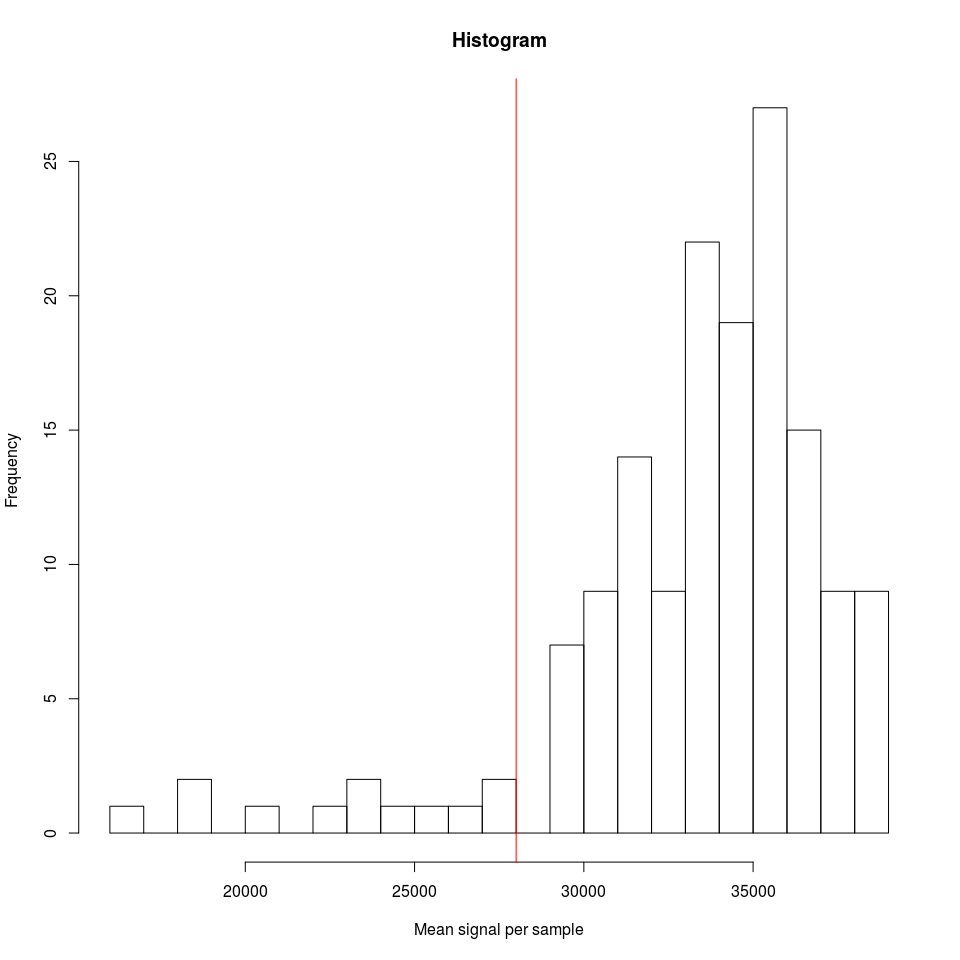

Raw Data Histogram

On the right of our threshold in Figure 1 are “normal” samples. The samples on the left side to it have a overall reduced mean signal intensity, indicating low quality (e.g. sample preparation, labelling or hybridization failed). To filter them out we use the `filt_samp` command:

```r
length(raw_napus$samples)
```

```
## [1] 304
```

```r
raw_napus <- filt_samp(raw_napus, check_raw(raw = raw_napus, plot = FALSE, thresh = 28000))
length(raw_napus$samples)
```

```
## [1] 280
```

### Number of beads

One indicator for data quality is the number of beads. The number of beads is included in the idat file and describes how many beads per signal have been used for each sample. In our data sets we see that the number of beads follows a bell-shaped distribution. Signals with a low number of beads (e.g. < 5) can be filtered out to increase the confidence of the value.

### Standard deviation

Similar to the filtering of the bead number, we can filter out signals based on the standard deviation. A high standard deviation indicates doubtful results. If a signal falls below a threshold it should be set to NA. If a SNP does not work in multiple samples, it should be filtered out entirely.

## Normalization

Microarray data usually show biased data due to technical errors. These biases can affect either the intensities of the individual colors or the overall intensity of the individual average (compare Figure 1). Detection of CNV need to quantify and compare the signal intensities within the array and between arrays. Therefore normalization of the data might be neccessary. We would expect similar distributions of both channels and use boxplots to visualize them.

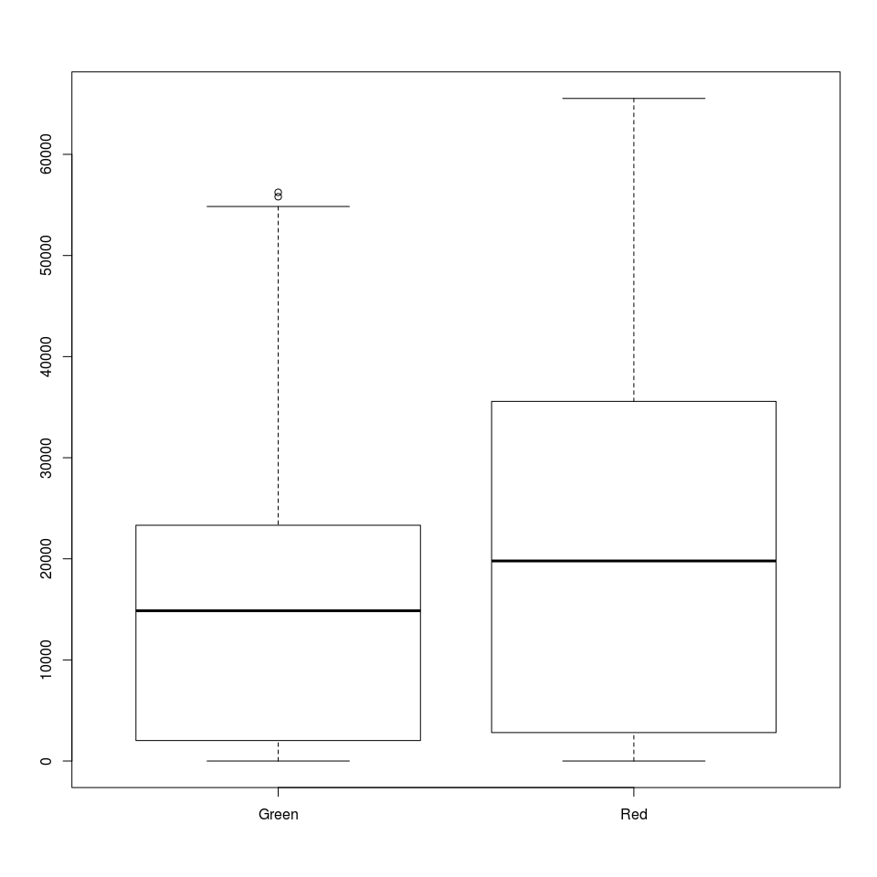

Boxplot comparing green and red signal distibutions

```r
boxplot(as.vector(raw_napus$raw[, seq(1, length(raw_napus$samples), 2)]),
        as.vector(raw_napus$raw[, seq(2, length(raw_napus$samples), 2)]),
        names = c("Green", "Red"))
```

Figure 2 shows that the intensities are quite different for the two channels. In our data set green values are lower than red values. In the output of the `check_raw` command we saw, that there is also a difference between the samples. A normalization is neccessary, as we expect all samples to have an overall similar signal intensity within and between samples. We provide four strategies:

- No normalization (not recommended)
- Quantile normalization (default)
- Mean normalization
- Combination of mean and quantile normalization

The latter one runs a quantiles normalization between the red and green signal intensities *within* each sample followed by a mean normalization *between* all samples. Best choice is to include a high number of samples of a diversity set, because crossing populations are biased.

## Transformation

The raw signals are heteroscedastic and a transformation is recommended. Again multiple ways are implemented ([Gidskehaug et al](http://bioinformatics.oxfordjournals.org/content/27/3/303.long) provide an illustrative comparison):

- No tranformation (not recommended)
- Log transformation (default)
- Fourth root transformation

## Scaling

Each SNP behaves differently on a chip and we recommend scaling of each SNP. Here we provide three ways:

- No scaling
- [Standardizing](https://en.wikipedia.org/wiki/Standard_score)
- Mean scaling (default)

The latter one subtracts for each SNP the difference between the SNP mean ${\mu}_{i}$ and the mean of all signals $\overline{\mu}$:
$${{S}_{i,j}} = {R_{i,j}} - ({{{\mu}_{i}} - {\overline{\mu}}})$$

Where ${R_{i,j}}$ and ${{S}_{i,j}}$ are the raw and scaled values, respectively. We use the constant $\overline{\mu}$ to prevent values below zero and keep them in a reasonable magnitude.

Green and red signals measure for one of two alleles (e.g. A or T). In order to call genotypes and CNVs we need the overall signal intensity of the red and green channel combined.

### Theta

Genotype information is described by the difference between the signal intensities ($\theta$). High red and low green signal intensities would indicate a homozygous “red genotype” and vice versa. Similar signal intensity strengths indicate heterozygous genotypes. There are different ways to calculate the signal intensity difference $\theta$. We use
$$\theta = \dfrac{atan2(y,x) \times 2 }{\pi}$$
where x and y are the green and red values, respectively.

### Intensity

The signal intensity provides information about the signal strength for a SNP. Low values indicate deletions and high values duplications. We use the p-norm to calculate intensity values from the two signals x and y (default $p=2$):
$$(x^p + y^p)^\frac{1}{p}$$

```r
norm_dat <- intens_theta(raw_napus, norm = "both", scaling = "mean", transf = "log")
str(norm_dat)
```

```
## List of 6
##  $ samples  : chr [1:140] "Sample_332_Grn" "Sample_328_Grn" "Sample_333_Grn" "Sample_329_Grn" ...
##  $ snps     : chr [1:40491] "Bn-A01-p10000230" "Bn-A01-p1001022" "Bn-A01-p10013185" "Bn-A01-p10026020" ...
##  $ chr      : chr [1:40491] "A01" "A01" "A01" "A01" ...
##  $ pos      : int [1:40491] 5435 6089 11833 80347 88548 89913 95658 97603 100381 100635 ...
##  $ intensity: num [1:40491, 1:140] 13.6 13 13.6 12 12 ...
##  $ theta    : num [1:40491, 1:140] 0.501 0.58 0.496 0.389 0.578 ...
##  - attr(*, "class")= chr "norm_data"
```

The object `norm_dat` contains the sample, SNP and location information from the raw data file. In addition the two matrices `intensity` and `theta` have been added containing the described intensity and theta values.

By default the sample names have a suffix, which should be remove because it is not informative.

```r
head(norm_dat$samples)
```

```
## [1] "Sample_332_Grn" "Sample_328_Grn" "Sample_333_Grn" "Sample_329_Grn"
## [5] "Sample_317_Grn" "Sample_334_Grn"
```

```r
norm_dat <- remove_suffix(norm_dat, "_Grn")
head(norm_dat$samples)
```

```
## [1] "Sample_332" "Sample_328" "Sample_333" "Sample_329" "Sample_317"
## [6] "Sample_334"
```

## Data check

We want to have a look at the data to see the outcome of the transformation.

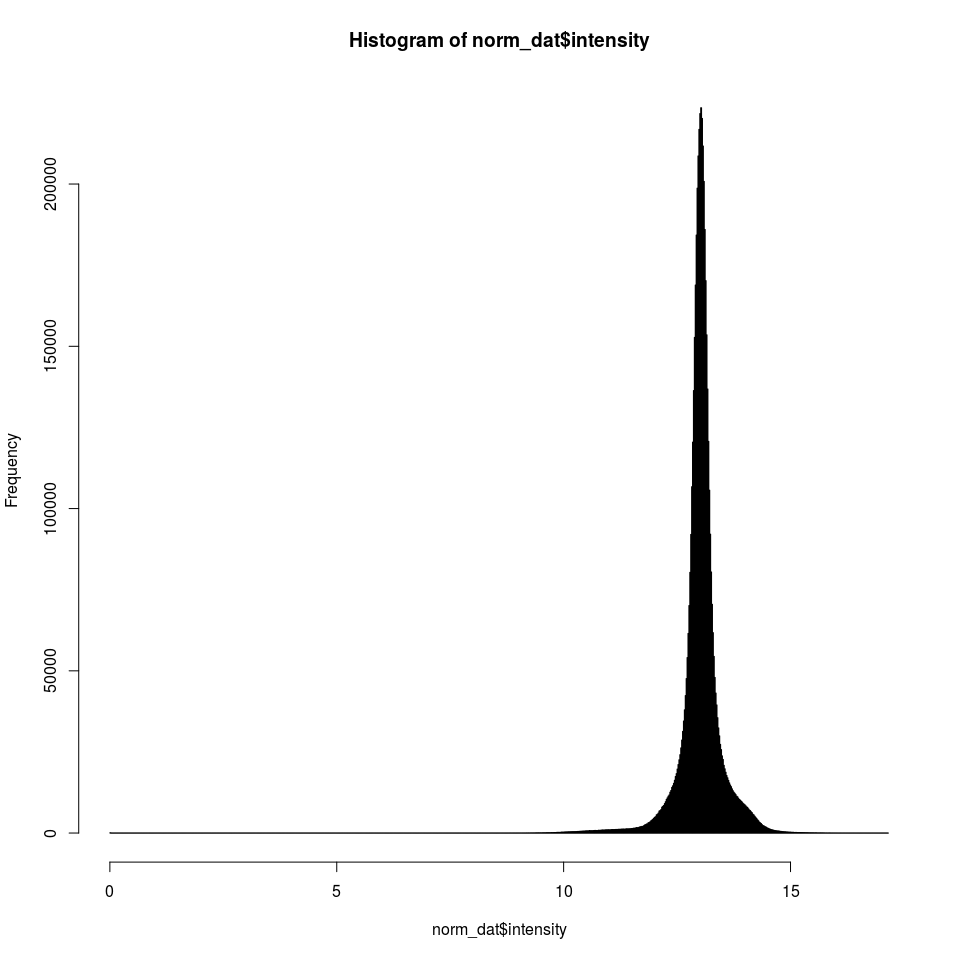

Intensity histogram

```r
hist(norm_dat$intensity, breaks = 1000)
```

The distribution in Figure 3 is dependend on the population. Usually, we see on large peak representing the “normal” signal intensity. Values or even peaks on the left indicate deletions. A minimum region between two peaks indicates a reasonable threshold for deletions.

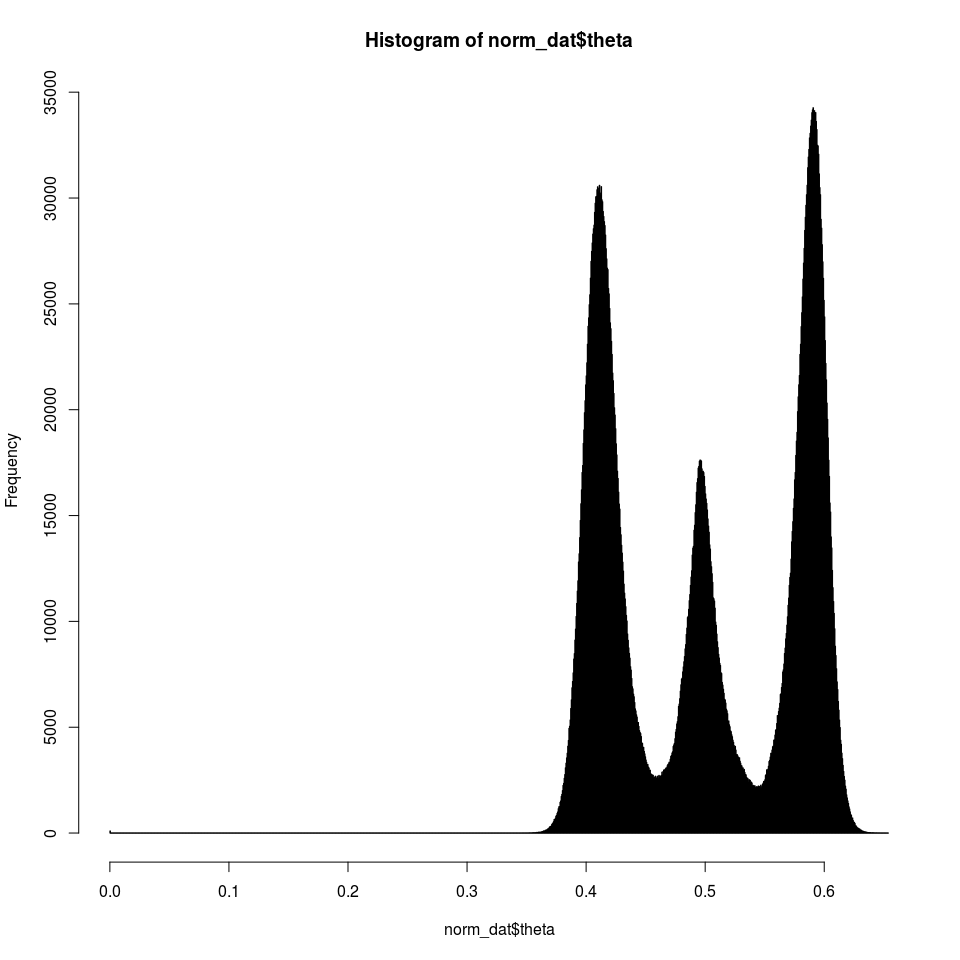

Theta histogram

```r
hist(norm_dat$theta, breaks = 1000)
```

We expect to see three peaks in Figure 4, one for the heterozygous and two for homozygous SNPs.

e are satisfied with our data and can move on with processing. The raw data is not longer required and we can free some memory:

```r
rm(raw_napus)
```

# Data Processing

Based on the theta and intensity values calculate **B-Allele frequencies** and **Log R ratios**.

## Genotype calling

We use a one dimensional k-means clustering from Ckmeans.1d.dp for the genotype calling. We treat each SNP as diploid and allow a maximum of three clusters.

## B-Allele frequency and Log R ratio

Based on the genotype calls, we calculate B-Allele frequency and Log R ratio as described by [Peiffer et al (2006)](http://www.ncbi.nlm.nih.gov/pmc/articles/PMC1557768/). B-Allele frequency values are noise reduced versions of the theta value we calculated before. Similarly, the Log R ratio is a corrected version of the intensity value. Both use the cluster means of the genotyping step to correct the values for each SNP individually. We apply a deletion threshold of 11 to remove lower values from the calculation. The threshold was obtained from the intensity histogram.

```r
norm_dat <- geno_baf_rratio(norm_dat, delthresh = 11)
str(norm_dat)
```

```
## List of 9
##  $ samples  : chr [1:140] "Sample_332" "Sample_328" "Sample_333" "Sample_329" ...
##  $ snps     : chr [1:40491] "Bn-A01-p10000230" "Bn-A01-p1001022" "Bn-A01-p10013185" "Bn-A01-p10026020" ...
##  $ chr      : chr [1:40491] "A01" "A01" "A01" "A01" ...
##  $ pos      : int [1:40491] 5435 6089 11833 80347 88548 89913 95658 97603 100381 100635 ...
##  $ intensity: num [1:40491, 1:140] 13.6 13 13.6 12 12 ...
##  $ theta    : num [1:40491, 1:140] 0.501 0.58 0.496 0.389 0.578 ...
##  $ baf      : num [1:40491, 1:140] NA 1 NA NA NA ...
##  $ geno     : num [1:40491, 1:140] NA 2 NA NA NA 1 2 2 NA 2 ...
##  $ rratio   : num [1:40491, 1:140] NA -0.00209 NA NA NA ...
##  - attr(*, "class")= chr "norm_data"
```

We see three new matrices in `norm_dat`:

- baf: B-Allele frequency information, ranging between 0 and 1.
- geno: Genotypes as called by k-means.
- rratio: Log R ratio values.

Again we have a look at the data:

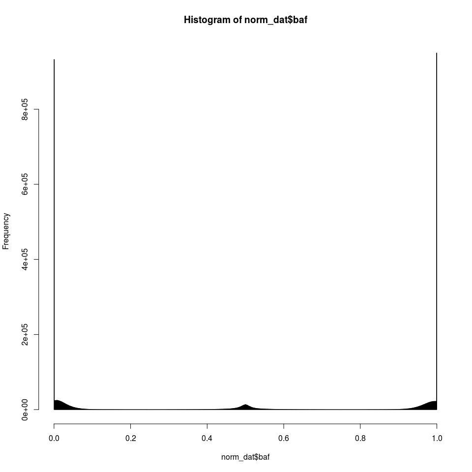

B-allele frequency histogram

```r
hist(norm_dat$baf, breaks = 1000)
```

The large peaks on the left and right side of Figure 5 indicate that most values are homozygous. The little bump at 0.5 indicates a small proportion of heterozygous SNPs.

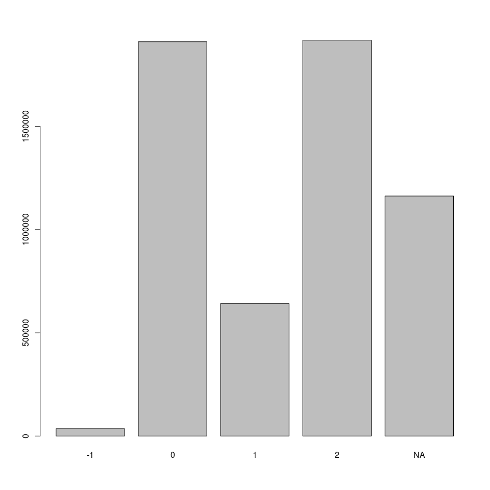

Barplot of genotypes

```r
tmp <- table(norm_dat$geno, useNA = "ifany")
barplot(tmp, names.arg = c(names(tmp)[1:4], "NA"))
```

The right bar in Figure 6 shows missing values (genotypes that could not be called). -1 indicates deletions. 0, 1 and 2 are the three diploid genotypes AA, AB and BB, respectively.

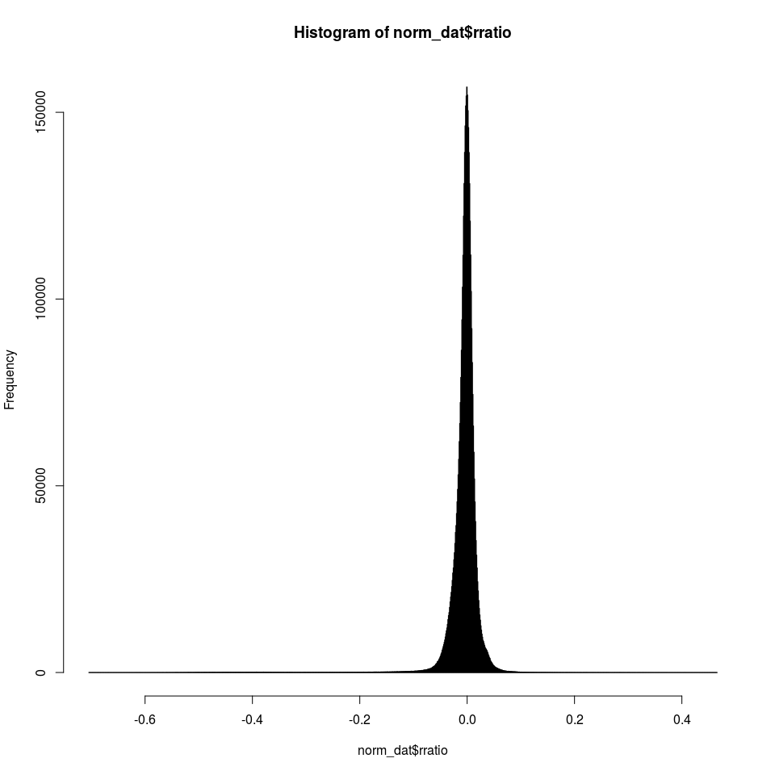

Log R ratio histogram

```r
hist(norm_dat$rratio, breaks = 1000)
```

The large peak in Figure 7 indicates that most SNPs are neither deleted nor duplicated. These would be indicated by smaller peaks on the left or right.

```r
norm_dat$theta <- norm_dat$intensities <- NULL
```

We filter out SNPs that could not be genotyped properly, because they did not show the expected segregation patterns or had too many values below the deletion threshold.

```r
length(norm_dat$snps)
```

```
## [1] 40491
```

```r
norm_dat <- filt_snps(norm_dat, norm_dat$snps[is.na(rowMeans(norm_dat$baf, na.rm = TRUE))])
length(norm_dat$snps)
```

```
## [1] 32184
```

## Segmentation and CNV calling

CNVs are called chromsomes-wise by segmentation of the data into continuous blocks with similar Log R ratios. We provide a wrapper to methods from the R package [*DNAcopy*](http://bioconductor.org/packages/release/bioc/html/DNAcopy.html). The function `segm` segments the data into continuous blocks of similar Log R ratio. The segments allow us to screen for CNV regions where multiple SNPs show the same pattern. It is resistant to individual SNPs with high or low Log R ratios and treats them as noise. We separate this step from the CNV calling because it is computationally expensive. That way we can call CNVs with varying thresholds without repeating the segmentation step.

```r
norm_dat <- segm(norm_dat)
str(norm_dat)
```

```
## List of 9
##  $ samples  : chr [1:140] "Sample_332" "Sample_328" "Sample_333" "Sample_329" ...
##  $ snps     : chr [1:32184] "Bn-A01-p1001022" "Bn-A01-p10031169" "Bn-A01-p10036602" "Bn-A01-p100441" ...
##  $ chr      : chr [1:32184] "A01" "A01" "A01" "A01" ...
##  $ pos      : int [1:32184] 6089 89913 95658 97603 100635 100921 101034 101391 101819 102098 ...
##  $ intensity: num [1:32184, 1:140] 13 13.8 13 13 13.2 ...
##  $ baf      : num [1:32184, 1:140] 1 0.518 1 0.986 0.962 ...
##  $ geno     : num [1:32184, 1:140] 2 1 2 2 2 2 2 0 0 2 ...
##  $ rratio   : num [1:32184, 1:140] -0.00209 0.00546 -0.00571 -0.00607 -0.0044 ...
##  $ cna      :'data.frame':   33048 obs. of  6 variables:
##   ..$ ID       : chr [1:33048] "Sample_332" "Sample_332" "Sample_332" "Sample_332" ...
##   ..$ chrom    : Factor w/ 19 levels "A01","A02","A03",..: 1 1 1 1 1 1 1 1 1 1 ...
##   ..$ loc.start: int [1:33048] 6089 14102936 14143364 14176341 18472417 18490451 24390933 24495043 26567822 26649357 ...
##   ..$ loc.end  : int [1:33048] 14088047 14142570 14174789 18471082 18487395 24387698 24471027 26551060 26648005 28480338 ...
##   ..$ num.mark : num [1:33048] 982 5 7 228 5 344 5 120 8 118 ...
##   ..$ seg.mean : num [1:33048] 0.0015 -0.0457 -0.1473 0.0027 -0.0286 ...
##  - attr(*, "class")= chr "norm_data"
```

The cna object `norm_dat` contains all segments of similar Log R ratios for all samples. To call CNVs we use the function `cnv`, with duplication and deletion thresholds of 0.03 and -0.06, as indicated by the Log R ratio histogram. `cnv` assigns segments as deletion, duplication or unchanged.

```r
norm_dat <- cnv(norm_dat, dup = 0.03, del = -0.06)
str(norm_dat)
```

```
## List of 10
##  $ samples  : chr [1:140] "Sample_332" "Sample_328" "Sample_333" "Sample_329" ...
##  $ snps     : chr [1:32184] "Bn-A01-p1001022" "Bn-A01-p10031169" "Bn-A01-p10036602" "Bn-A01-p100441" ...
##  $ chr      : chr [1:32184] "A01" "A01" "A01" "A01" ...
##  $ pos      : int [1:32184] 6089 89913 95658 97603 100635 100921 101034 101391 101819 102098 ...
##  $ intensity: num [1:32184, 1:140] 13 13.8 13 13 13.2 ...
##  $ baf      : num [1:32184, 1:140] 1 0.518 1 0.986 0.962 ...
##  $ geno     : num [1:32184, 1:140] 2 1 2 2 2 2 2 0 0 2 ...
##  $ rratio   : num [1:32184, 1:140] -0.00209 0.00546 -0.00571 -0.00607 -0.0044 ...
##  $ cna      :'data.frame':   33048 obs. of  6 variables:
##   ..$ ID       : chr [1:33048] "Sample_332" "Sample_332" "Sample_332" "Sample_332" ...
##   ..$ chrom    : Factor w/ 19 levels "A01","A02","A03",..: 1 1 1 1 1 1 1 1 1 1 ...
##   ..$ loc.start: int [1:33048] 6089 14102936 14143364 14176341 18472417 18490451 24390933 24495043 26567822 26649357 ...
##   ..$ loc.end  : int [1:33048] 14088047 14142570 14174789 18471082 18487395 24387698 24471027 26551060 26648005 28480338 ...
##   ..$ num.mark : num [1:33048] 982 5 7 228 5 344 5 120 8 118 ...
##   ..$ seg.mean : num [1:33048] 0.0015 -0.0457 -0.1473 0.0027 -0.0286 ...
##  $ cnv      : num [1:32184, 1:140] 0 0 0 0 0 0 0 0 0 0 ...
##  - attr(*, "class")= chr "norm_data"
```

We added a `cnv` object to `norm_dat`, which contains the CNV calls for all SNPs and samples. A CNV call is a block of SNPs where most SNPs are above or below a individually defined threshold.

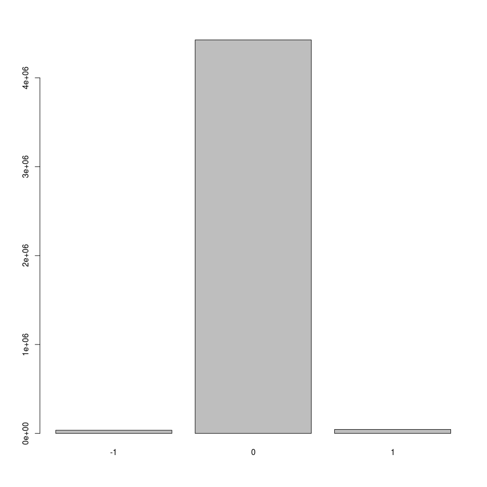

Barplot of CNVs

```r
barplot(table(norm_dat$cnv))
```

-1, 0 and 1 in Figure 8 are deletions, normal calls (no CNV aberrations) and duplications, respectively.

## Translocations / homeologous exchanges

We can call translocation from the CNV data. For each sample we screen all synteny blocks for reciprocal translocations, i.e. if there are duplications on one side of the synteny block and a deletion on the other. Using the parameters we can specify the minimum number of SNPs in each event, individually. Further, we can set a maximal difference of SNPs between reciproval events to avoid erroneous translocation calls by independent events, which are in the same synteny block by chance. We require at least 5 SNPs to be duplicated/deleted to increase the quality of our prediction. We create a synteny block object from either mapped genes or reference sequences, as explained in the synteny block vignette.

```r
data(synteny_blocks, package = "brassicaData", envir = environment())
```

```r
norm_dat <- trans_location(norm_dat, synteny_blocks, min1 = 5, min2 = 5, maxdiff = 10)
```

# Visualization of the results

We completed all necessary data processing steps. Now, we look at our results:

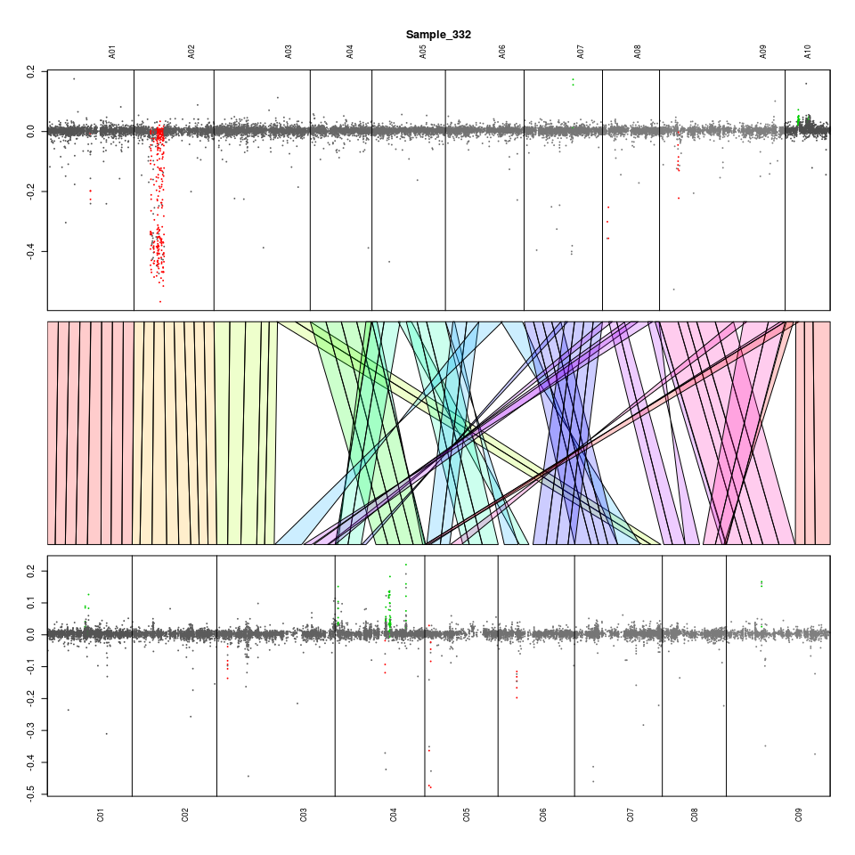

Genome structure rearrangements within one sample

```r
plot_gsr(norm_dat, sb = synteny_blocks, samp = 1)
```

Log R ratios of A and C chromosomes are plotted on top and bottom of Figure 9, respectively. Grey, Red and Green, indicate normal, deleted and duplicated SNPs. In between are synteny blocks indicating homeology between the two subgenomes. The colors correspond to the synteny block location in the A genomes.

We can add the B-Allele frequency and translocations, setting the options `baf` and `tl` to TRUE.

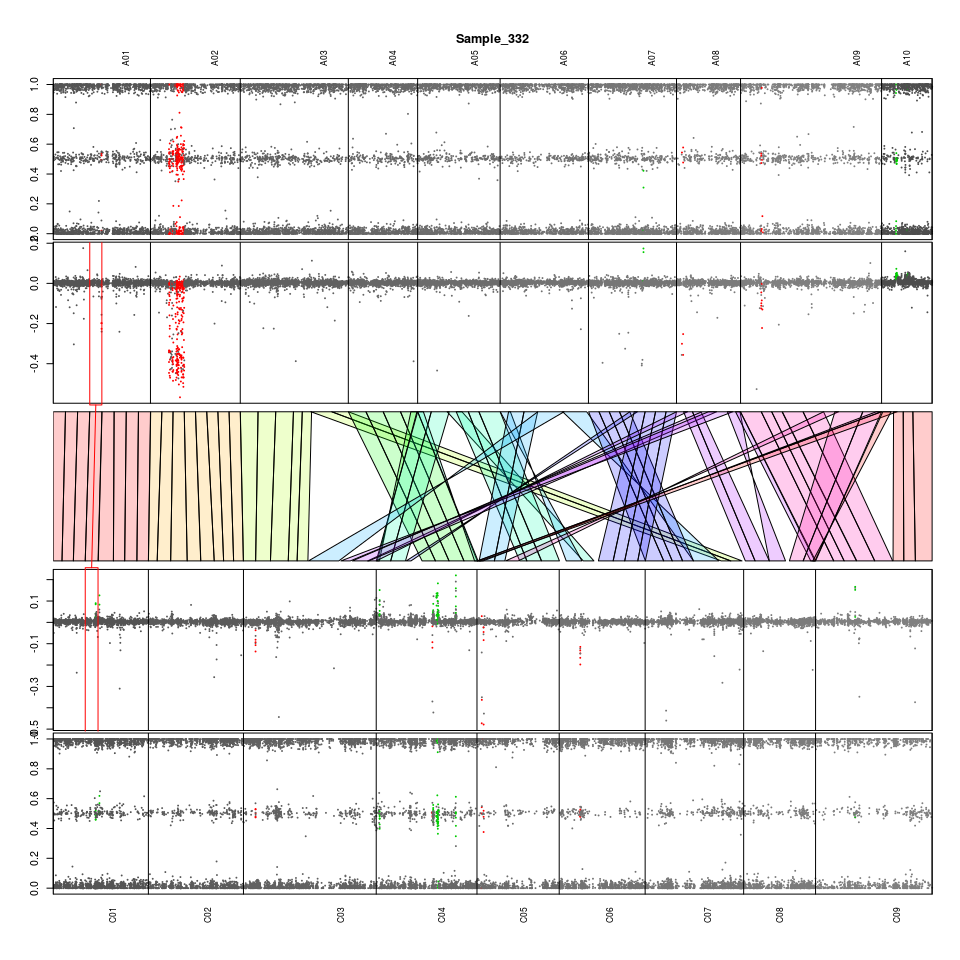

Genome structure rearrangements within one sample, inluding B-allele frequencies and translocations

```r
plot_gsr(norm_dat, sb = synteny_blocks, samp = 1, baf = TRUE, tl =TRUE)
```

Figure 10 shows the same plot as before, but with B-Allele frequencies included and translocations highlighted.

In addition to individual samples, we can plot the whole mean values for the whole dataset. It allows us to find deletion and duplication hotspots.

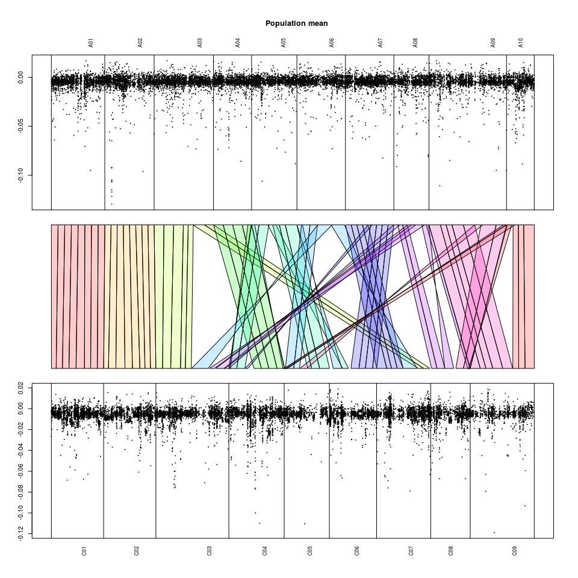

```r
plot_global(norm_dat, sb = synteny_blocks)
```

Figure 11 shows the global plot with mean values of all samples.